# A1.1 612656

A continuacion se escriben lineas de codigo donde se importa la libreria de 'pandas' para poder usar algunas de las funciones de la libreria. En este caso se usa la funcion 'read_csv' de pandas para abrir el archivo 'A1.1 Obesidad.csv', y estos datos los asignamos a la variable 'data'. Por ultimo con la funcion 'head' mostramos los primeros 10 datos en el archivo guardado en 'data'. Esto dando como resultado una tabla con los campos de Sexo, Edad, Estatura, Peso, FamiliarConSobrepeso, entre otros y su respectivos datos, que incluyen tanto cualitativos como cuantitativos, como lo puede ser la edad, estatura o peso, o el si tiene o no un familiar con sobre peso, si come muchas calorias, si es fumador, etc.

```python
import pandas as pd
data = pd.read_csv("A1.1 Obesidad.csv")
data.head(10)
```

|  | Sexo | Edad | Estatura | Peso | FamiliarConSobrepeso | ComeMuchasCalorias | ComeVegetales | Fumador | ConsumoDeAgua | NivelDeObesidad |
| --- | --- | --- | --- | --- | --- | --- | --- | --- | --- | --- |
| 0 | Female | 21.0 | 1.62 | 64.0 | yes | no | 2.0 | no | 2.0 | Normal_Weight |
| 1 | Female | 21.0 | 1.52 | 56.0 | yes | no | 3.0 | yes | 3.0 | Normal_Weight |
| 2 | Male | 23.0 | 1.80 | 77.0 | yes | no | 2.0 | no | 2.0 | Normal_Weight |
| 3 | Male | 27.0 | 1.80 | 87.0 | no | no | 3.0 | no | 2.0 | Overweight_Level_I |
| 4 | Male | 22.0 | 1.78 | 89.8 | no | no | 2.0 | no | 2.0 | Overweight_Level_II |
| 5 | Male | 29.0 | 1.62 | 53.0 | no | yes | 2.0 | no | 2.0 | Normal_Weight |
| 6 | Female | 23.0 | 1.50 | 55.0 | yes | yes | 3.0 | no | 2.0 | Normal_Weight |
| 7 | Male | 22.0 | 1.64 | 53.0 | no | no | 2.0 | no | 2.0 | Normal_Weight |
| 8 | Male | 24.0 | 1.78 | 64.0 | yes | yes | 3.0 | no | 2.0 | Normal_Weight |
| 9 | Male | 22.0 | 1.72 | 68.0 | yes | yes | 2.0 | no | 2.0 | Normal_Weight |

Luego se imprime un mensaje donde se indica una variable que se considero 'faltante' o que podriamos tomar a consideracion en esta investigacion y que tipo de dato se consideraria, ya sea cuantitativa o cualitativa. Que en este caso hablamos de agregar el aspecto de actividad fisica y les asignamos algunos rangos a su frecuencia como lo es un no hace(0), de 1 a 2 dias (1), de 3 a 5 dias (2) o mas de 5 dias (3), y con esto llegamos a la conclusion de que es cuantitativa.

```python
print("Un aspecto que no se toma a considerar aqui es la 'actividad fisica', podriamos integrar este parametro como un aspecto cuantitativo donde midamos en rangos la frecuencia que el paciente hace actividad fisica. Desde un no hace(0), de 1 a 2 dias (1), de 3 a 5 dias (2) o mas de 5 dias (3)")
```

```
Un aspecto que no se toma a considerar aqui es la 'actividad fisica', podriamos integrar este parametro como un aspecto cuantitativo donde midamos en rangos la frecuencia que el paciente hace actividad fisica. Desde un no hace(0), de 1 a 2 dias (1), de 3 a 5 dias (2) o mas de 5 dias (3)
```

Ahora con ayuda de la misma libreria 'pandas' usaremos la funcion de 'value_counts' para contar cuantas personas hay en cada uno de los diferentes tipos de nivel de obesidad que se encuentran en nuestra variable 'data'.

```python
# peso como entrada / nivel como salida
import pandas as pd
print(data.NivelDeObesidad.value_counts())
```

```
NivelDeObesidad
Obesity_Type_I         351
Obesity_Type_III       324
Obesity_Type_II        297
Overweight_Level_I     290
Overweight_Level_II    290
Normal_Weight          287
Insufficient_Weight    272
Name: count, dtype: int64
```

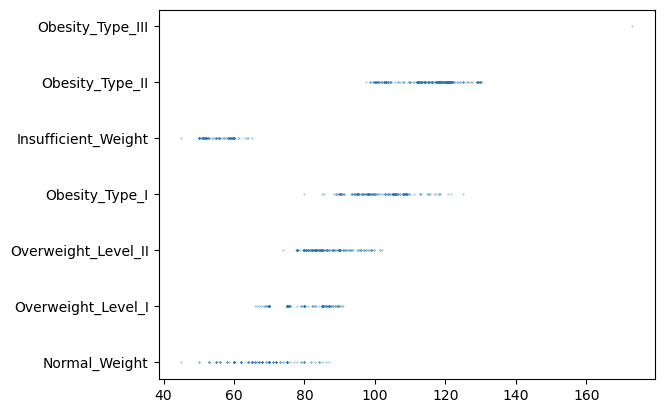

```python
%matplotlib inline

import matplotlib.pyplot as plt
x = data.Peso[data.Sexo == "Male"]
y = data.NivelDeObesidad[data.Sexo == "Male"]
alpha = 0.05
plt.show(plt.scatter(x,y,alpha))
```